# Remembering and Forgetting

PSYC302

Paul D. Kieffaber, Ph.D.

April 16, 2026

# The Origins of Memory Research

Historical Context

- The experimental study of memory dates back to the 1880s with the publication of Hermann Ebbinghaus’ research.
- Ebbinghaus was the first to believe that rigorous experimental methods could be applied to “higher” cognitive functions.

**Neuroanatomical Milestones:** Around this exact same time (1873-1887), Camillo Golgi developed the “Golgi stain” and Ramón y Cajal first observed individual neurons.

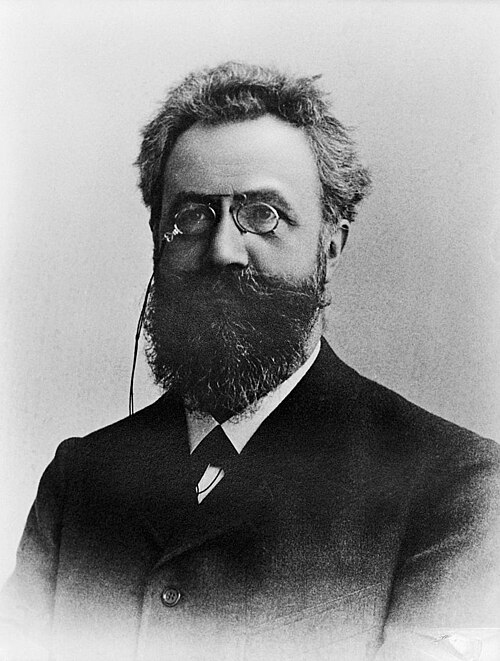

Hermann Ebbinghaus (1850–1909)

# Measuring Memory: The Ebbinghaus Tradition

## Methodology:

He was the only subject in all of his research

Used lists of “CVC nonsense syllables”

1. Read the list aloud, cover it up, and try to recall.
2. Measure “trials to criterion” (attempts to recite perfectly).
3. Wait a specific retention interval, then relearn the list.
4. The Savings Score: ((Original Learning - Relearning) / Original Learning) * 100

ZOC

VAP

TOK

BUP

KET

ZOD

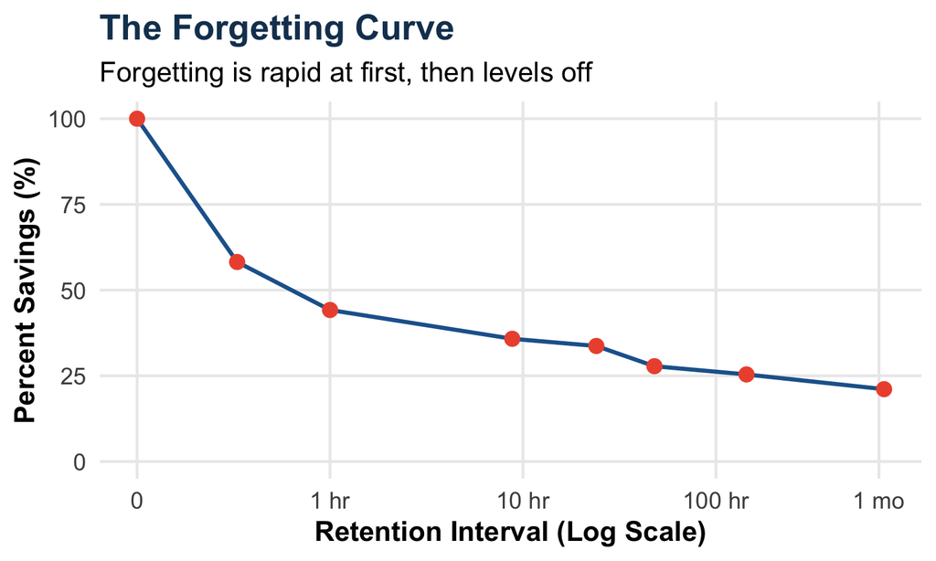

He noted that the forgetting curve was not linear, but declined rapidly over the first hour, then gradually over subsequent retention intervals.

# The Information Processing Model

Three Distinct Stages

Note that Ebbinghaus’ approach relied on a fairly simplistic definition of memory - how long things last.

Modern experimental psychology conceptualizes memory as moving through three information processing stages.

### Encoding

The process of taking incoming sensory information and converting it into a form that the brain can process and store.  
*(Studied by manipulating how people study).*

### Storage

The passive or active maintenance of information over time.  
*(Studied by manipulating retention intervals or introducing interference).*

### Retrieval

The process of accessing and bringing stored information back into conscious awareness.  
*(Studied by manipulating how memory is tested).*

# Traditional Methods: Studying Encoding

Manipulating the Study Phase

How does the way we interact with information at the time of learning dictate what is actually stored? Researchers manipulate study conditions to find out.

### Levels of Processing

*Craik & Lockhart (1972)* proposed that memory relies on the “depth” of attention paid to stimuli during study:

- **Graphemic:** Physical features *(e.g., Is the word in uppercase?)*
- **Phonemic:** Acoustic features *(e.g., Does it rhyme with chair?)*
- **Semantic:** Meaning-based *(e.g., Is it a living thing?)*

**Critique:** The theory risks tautology. We say a word was processed deeply because it was remembered well, but explain that it was remembered well because it was processed deeply.

### Robust Encoding Phenomena

- **The Generation Effect:** Actively producing a target word (e.g., generating *cold* from the cue `hot - c___`) leads to significantly stronger memory than passively reading the complete pair.
- **The Self-Reference Effect:** Evaluating stimuli based on how well they describe *you personally* yields even deeper encoding and better recall than standard semantic processing.

# Traditional Methods: Studying Storage

Preventing Rehearsal

How is information maintained in short-term memory, and how do we lose it? To isolate “storage” as a variable, researchers must prevent the subject from actively rehearsing the information.

### The Brown-Peterson Task

Designed in the late 1950s, this task measures the duration of short-term memory by blocking the articulatory loop.

- **Stimulus:** Present a consonant trigram (e.g., `C H J`).
- **Distractor Task:** Immediately present a random 3-digit number (e.g., `506`) and ask the subject to count backward by 3s aloud.
- **Delay:** Vary the retention interval (usually 0 to 18 seconds).
- **Test:** Ask the subject to recall the trigram.

**What does this measure?**  
By occupying the mind with a demanding math task, researchers initially believed they were measuring the pure **decay** of a memory trace over time. Later research revealed they were actually measuring **interference**.

# Class Demonstration

Experiencing the Paradigm

### Instructions

1. You will see three consonants appear on the screen.
2. Immediately after, a number will appear.
3. **Start counting backward by 3s ALOUD from that number.**
4. When the screen says **“RECALL”**, write down the three letters.

# Trial 1 Stimulus

# F Z M

# Trial 1 Interference

# 8 4 1

# Trial 2 Stimulus

# P C S

# Trial 2 Interference

# 7 8 4

# The Results: Interference

Why does it get harder?

If we did multiple trials, you would likely find the first trial relatively easy, but the 4th or 5th trial extremely difficult. Why?

**Proactive Interference (Keppel & Underwood, 1962):** - Old information (previous trials) interferes with the ability to store and retrieve new information (the current trial). - Without rehearsal, the memory trace becomes highly susceptible to this interference.

If we suddenly switched the stimulus from letters to shapes, your memory would immediately bounce back to near 100%!

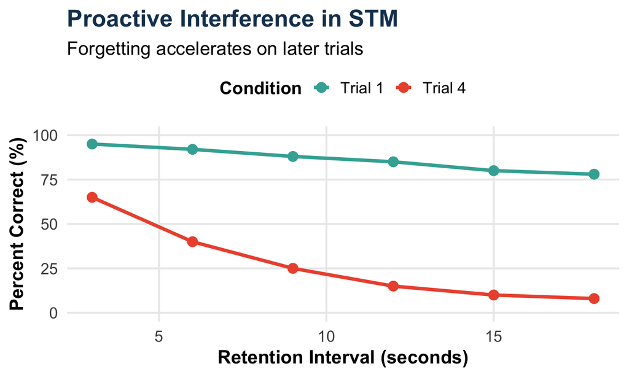

# Stop and Think

Methodological Critique

### Internal Validity?

- Are we truly isolating the specific memory process we claim to be studying?
- Did the independent variable *actually* cause the change in the dependent variable, or was there a confounding factor (like fatigue or guessing)?

### External Validity?

- How artificial is the laboratory paradigm?
- To what situations, populations, stimuli, etc. does this result generalize?
- Does learning a list of CVC nonsense syllables predict how well you will remember a face or a textbook chapter?

# Traditional Methods: Studying Retrieval

Test Design Matters

Memory performance is heavily dependent on **how** the memory is tested. The dependent variable determines what kind of memory you are accessing.

### Recall Tasks

- **Serial Recall:** Reproduce material in the exact original order (e.g., digit span).
- **Free Recall:** Order of retrieved items is irrelevant.
- **Paired-Associate Recall:** Cue-Target (e.g., `igloo-saloon -> igloo- __`).

### Recognition Tasks

- **Explicit Recognition:** Usually forced choice, such as identifying items as “Old” or “New”.
- Heavily relies on *Signal Detection Theory* to separate true memory (sensitivity) from guessing (response bias).

# Beyond the Modal Model

Systems of Memory

The 1960s “modal model” assumed memories passed sequentially from a low-capacity Short-Term store to a high-capacity Long-Term store. Modern theories recognize distinct *systems*.

- **Explicit (Episodic) Memory:** Conscious recollection of specific events or episodes.
- **Implicit Memory:** Expression of learning with no conscious retrieval.
  - *Procedural:* Motor skills (e.g., riding a bike).
  - *Priming:* Enhanced processing of a stimulus due to recent exposure.

How do we know these systems are actually different, rather than just different types of tests? We look to **Neuropsychology**.

# Quasi-Experimental Approaches: Brain Damage

The Logic of Dissociation

We cannot randomly assign brain lesions to human subjects. We must study naturally occurring damage, comparing patients to healthy controls using a **Quasi-Experimental Design**.

- **Why it matters:** Brain injury provides unique insights into how memory systems are physically segregated in the brain.
- **Single Dissociation:** Patient loses function A but retains function B.
- **Double Dissociation:** Patient 1 loses A but keeps B; Patient 2 loses B but keeps A. This is the gold standard for proving two systems rely on different neural mechanisms!

# Classical Neuropsychological Cases

H.M. and Amnesia

**Patient H.M.** - Underwent bilateral medial temporal lobe resection to treat severe epilepsy. - Developed profound **anterograde amnesia** (cannot form new explicit memories). - Consolidation of long-term?

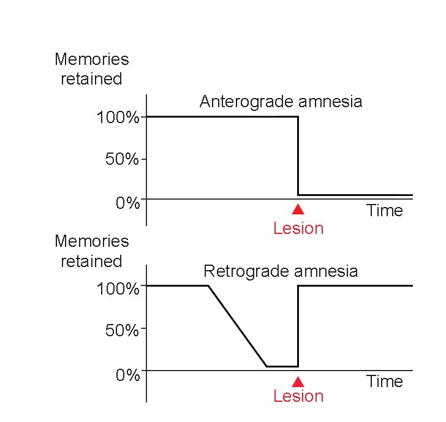

# Classical Neuropsychological Cases

H.M. and Implicit Memory

**Patient H.M.** - **Spared Implicit Memory:** Improved at the “mirror tracing” task over consecutive days, despite having zero conscious memory of ever doing the task.

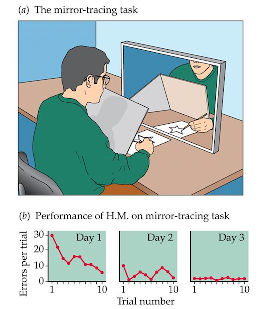

# Classical Neuropsychological Cases

Hemifield Neglect Syndrome

- Caused by damage to parietal cortex (usually right)
- When images are presented bilaterally, the one on the left is **extinguished**
- Researchers used fragmentation index to measure implicit memory for extinguished pictures.

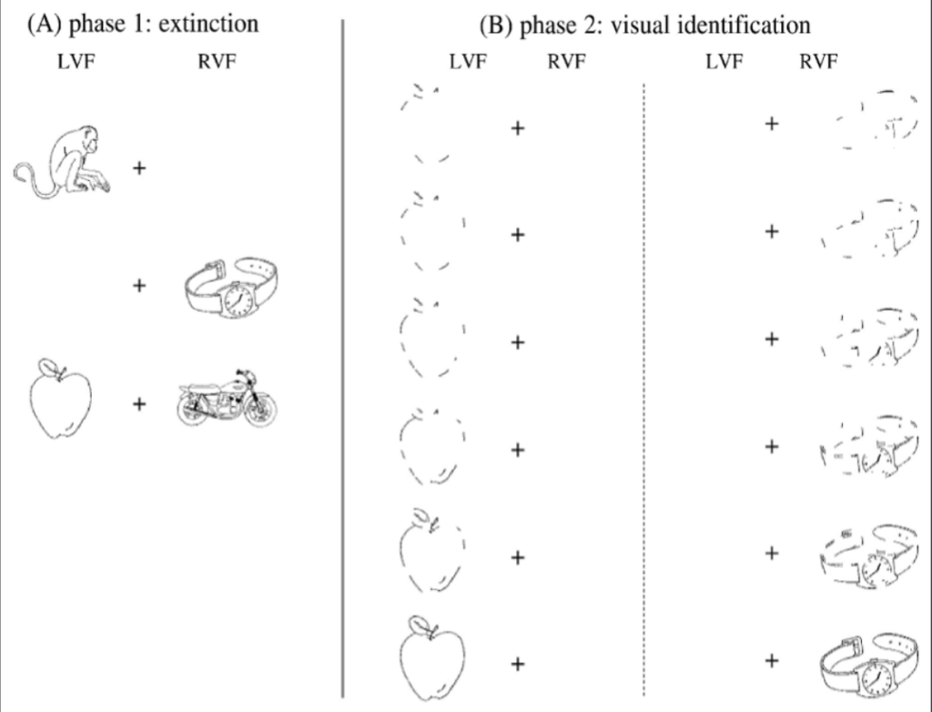

# Classical Neuropsychological Cases

Hemifield Neglect Syndrome

## Results

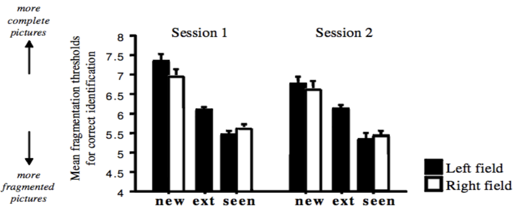

# Interactions are Used to Indicate Distinct Systems

Factorial Designs

How do we know implicit and explicit memory are truly different systems in healthy brains? We look for **Interaction Effects**.

**The Picture Superiority Effect:** - *Explicit Recall Test:* Pictures are remembered much better than words. - *Implicit Priming Test:* Priming effects are significantly stronger for words than for pictures.

This cross-over interaction strongly supports the theory that explicit recall and implicit priming rely on distinct underlying cognitive architectures.

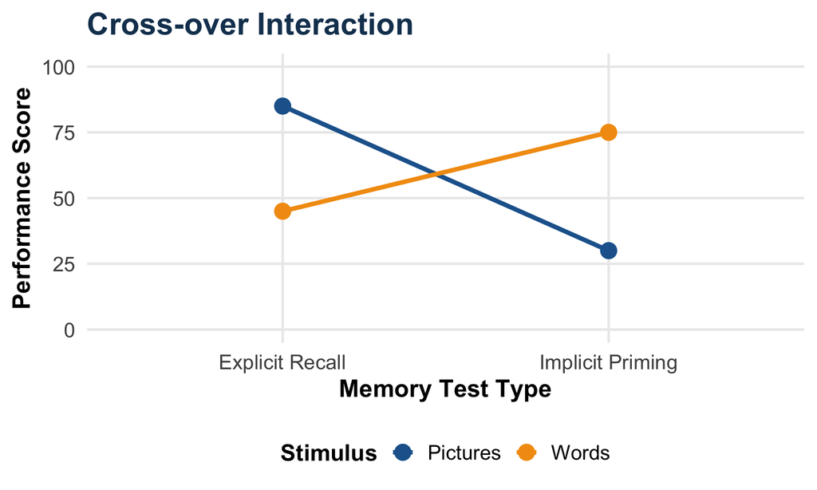

# Emotion and Memory Encoding

The Weapon Focus Effect

How does intense physiological arousal and emotion alter *what* we encode into memory? *Easterbrook (1959)* and *Christianson (1992)* studied this using the “Weapon Focus” paradigm.

### Independent Variable 1: Arousal State

Subjects are presented with a visual scene (e.g., a slide sequence or video) that varies in emotional intensity: - **Neutral Condition:** A person holding a harmless object (e.g., a check at a bank counter). - **Emotional/Violent Condition:** A person holding a threatening object (e.g., a gun at a bank counter).

### Independent Variable 2: Detail Type

Researchers then test memory for two distinctly different types of information within that same scene: - **Central Details:** Information directly tied to the focal point of the scene (e.g., the attacker’s face, the weapon itself). - **Peripheral Details:** Background information (e.g., the color of a car outside, the clothes of a bystander).

# The Spotlight of Arousal

When we look at the results, we don’t see a simple main effect where emotion makes *all* memory better or worse. Instead, we see a massive interaction.

- **Under normal conditions**, we encode a relatively balanced picture of central and peripheral details.
- **Under high arousal**, memory for central details drastically *increases*, while memory for peripheral details drastically *decreases*.

**The Takeaway:** Emotion acts like a spotlight. It doesn’t uniformly enhance or degrade memory; rather, it concentrates our limited encoding resources squarely on the threat at the severe expense of the background.

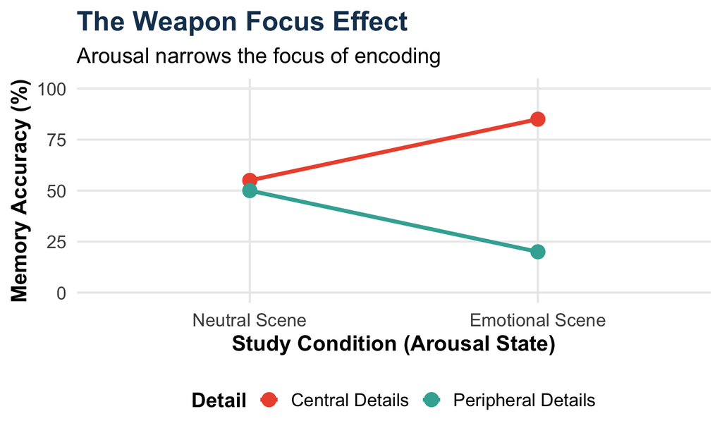

# Beyond Levels of Processing

Transfer-Appropriate Processing

Did the “Levels of Processing” theory tell the whole story? *Morris, Bransford, and Franks (1977)* designed an experiment to test if “deep” semantic processing is truly *always* better.

### Independent Variable 1: Study Task

Subjects encoded words under two different conditions: - **Semantic (Deep):** Does the word fit in a sentence? *(e.g., “The _____ had a silver engine.” -> TRAIN)* - **Phonemic (Shallow):** Does the word rhyme with another word? *(e.g., “_____ rhymes with legal.” -> EAGLE)*

### Independent Variable 2: Test Type

Crucially, the researchers varied the dependent variable, giving subjects one of two tests: - **Standard Recognition:** Was “TRAIN” on the list? *(Relies on memory for meaning).* - **Rhyming Recognition:** Was there a word on the list that rhymes with “BRAIN”? *(Relies on memory for sound).*

# Matching Encoding and Retrieval

A Cross-over Interaction

The results revealed a massive interaction that fundamentally changed how we view memory.

- On the **Standard Test**, Semantic study won out. This perfectly replicates the classic Levels of Processing effect.
- However, on the **Rhyming Test**, Phonemic study significantly outperformed Semantic study!

**The Takeaway:** “Deep” semantic processing isn’t inherently better. Memory is optimized when the cognitive processes used during encoding **match** the processes required during retrieval.

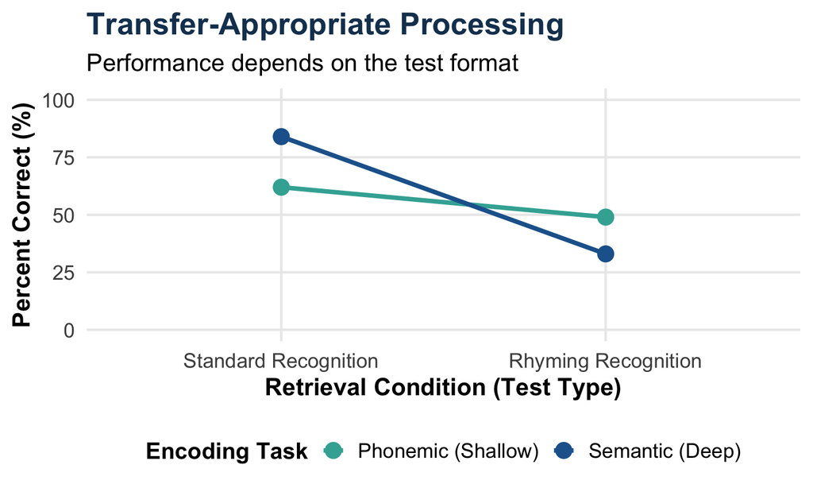

# Sternberg Memory Scanning

Classic memory RT paradigm

**Basic question:** How does reaction time change as the number of items in short-term memory increases?

The key manipulation was **memory set size**. If searching memory takes time, then reaction time should increase as the set gets larger.

# Main finding

Reaction time increases linearly

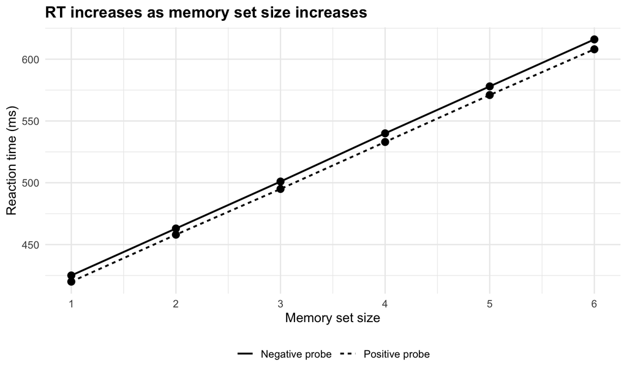

- RT increased in a roughly **linear** way as more items had to be remembered.
- This suggests that each additional memory item added a fairly constant amount of processing time.
- Positive and negative probes had **similar slopes**.

A linear increase in RT with set size suggests that people scan items in short-term memory one by one.

# Why the study was important

Theoretical interpretation

Sternberg argued that short-term memory search is:

- **serial**: items are checked one at a time
- **exhaustive**: the whole set is scanned, even if a match is found early

### Why exhaustive?

If people stopped as soon as they found a match, then: - **positive** trials should be faster than **negative** trials - and the positive slope should be smaller

But the classic result showed: - similar slopes for **YES** and **NO** responses

This was surprising because it suggested that people often continue scanning memory even after finding the target.

# Questions for class discussion

- Why does a linear RT increase support a serial search model?

  **Answer**

  Because if the search were parallel, it would take the same amount of time no matter how many items were being searched.
- Why do similar slopes for positive and negative probes support an exhaustive search model?

  **Answer**

  Because if the search were self-terminating, positive trials should often end earlier and produce a shallower slope. Similar slopes suggest the full memory set is scanned even when the probe is present.